# Risk Analysis

Diego Vallarino

2022-05-09

Let’s do an exercise with real but anonymous data. Suppose we take a kind of risk score from different companies in the same sector. The score goes from 1 to 100, but we cut them by deciles. That’s the first column. Now we take the same data (company scores) in another sector.

| ...1 | ...2 |
| --- | --- |
| 4 | 9 |
| 7 | 8 |
| 6 | 4 |
| 8 | 6 |
| 7 | 5 |
| 5 | 9 |

Then we graph how the evolution of the scores behaved for each company in each sector over time. We see that there is a trend change in one sector *(red)* than in the other sector *(black)*.

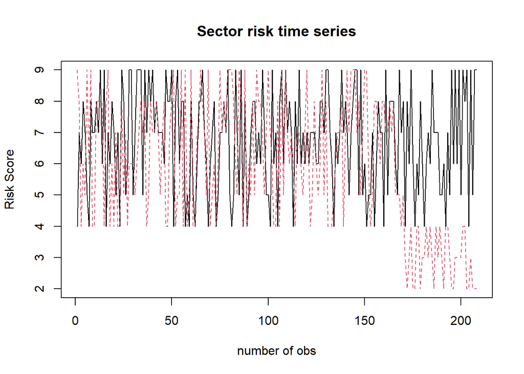

We see that on the date there is a specific event that has impacted one sector and another not. To continue with anonymity, we can say that the effect can be: a) the breakdown of a relevant player in the red sector, b) the exposure of the red sector to the war in Ukraine, c) the bottlenecks in the processes of supply chain.

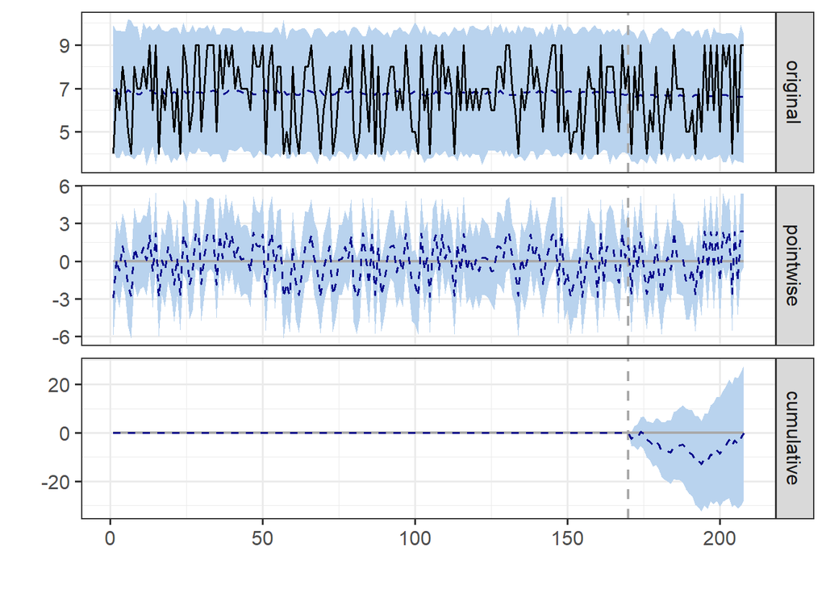

```
## Posterior inference {CausalImpact}
##
##                          Average         Cumulative
## Actual                   6.7             253.0
## Prediction (s.d.)        6.7 (0.37)      252.9 (14.06)
## 95% CI                   [5.9, 7.4]      [225.1, 281.0]
##
## Absolute effect (s.d.)   0.0016 (0.37)   0.0610 (14.06)
## 95% CI                   [-0.74, 0.73]   [-27.95, 27.90]
##
## Relative effect (s.d.)   0.024% (5.6%)   0.024% (5.6%)
## 95% CI                   [-11%, 11%]     [-11%, 11%]
##
## Posterior tail-area probability p:   0.49908
## Posterior prob. of a causal effect:  50%
##
## For more details, type: summary(impact, "report")
```

[output not shown]